# Report for ANCOVA and Dunnett’s of Pearson SS

Jory Curry

24 November 2022

# Toxicology Behavioural Analysis Report

## Version Control

```r
# - My Machine Info:
#   - R version 4.2.1 (2022-06-23)
#   - Platform: x86_64-pc-linux-gnu (64-bit)         5.11.0-34-generic / Ubuntu 22.04.1 LTS
#   - Desktop: GNOME 3.36.5
#   - Hardware: CPU - Intel Core i5-9400F 6 core 4.1GHz / RAM - 15924MiB
```

## Analysis - Similarity Scores/Correlation coefficients

Curvep is a heuristic algorithm for dose-response curve processing. It assumes monotonicity, but does not fit curve to observed responses (as isotonic regression). Instead, it minimizes the number of corrections that need to be made to restore monotonicity. OR CurveP assumes each dose–response curve has to exhibit monotonic behavior: increasing, decreasing, or flat (constant), and tries to find a minimal set of correctable test points to achieve that

Key parameters are baseline noise threshold (-THR=) - points with smaller response are suppressed maximum allowed deviation from the monotonicity (-MXDV=) - affects adjacent points range of response values (-RNG=) - can be negative (e.g., inhibition) or positive (e.g., agonism)

The POD (BMD for similarity scores) is defined as the concentration at which the response exceeds the assay-dependent noise threshold and is calculated by linear interpolation between the two concentration points, where their range of response includes the noise threshold.

The wAUC is the product of the point of departure (POD) and the AUC, normalized by the test concentration range:

wAUC = (AUC/range of concentration)*POD

I propose: instead of flagging active chemicals with an ANOVA (because we are violating normality assumptions) we use an approach similar to the following (which the authors of the RcurveP package have done before):

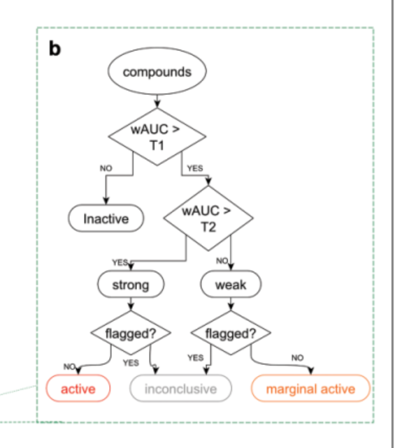

Pipeline

CurveP’s major limitation is its tacit dependency on a given order of test concentrations. Those are treated as a predefined sequence of measurements, and in case of irregularly spaced test concentrations or changes in their number or range for different samples, the comparisons of resulting CurveP values will be biased.

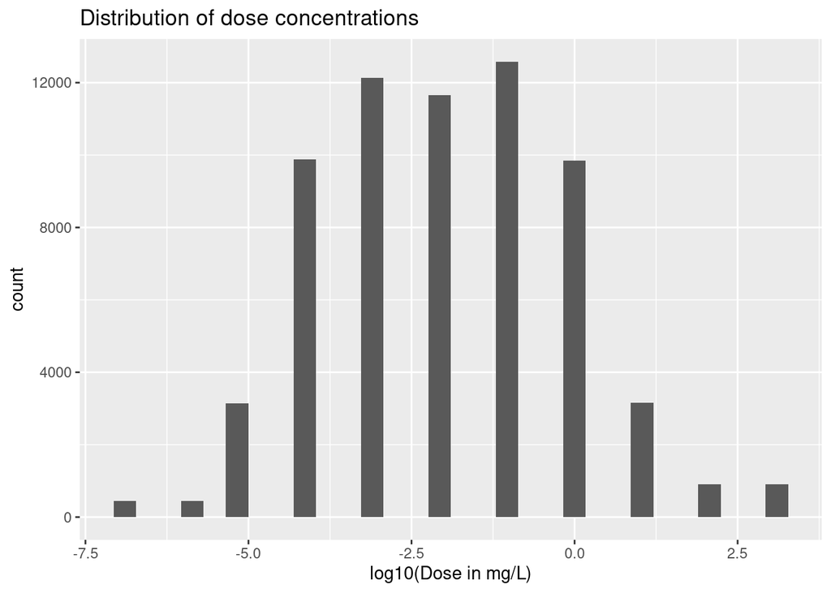

CurveP is biased towards those samples that fall under the log dose range of -5 (0.00001mg/L) to 1 (10mg/L).

Those chemicals that have dose range beyond this include: - DMF (Highest 1000) - TEG (Highest 100) - EE2 (Lowest 0.0000001)

Therefore, I think that should be excluded from the training set.

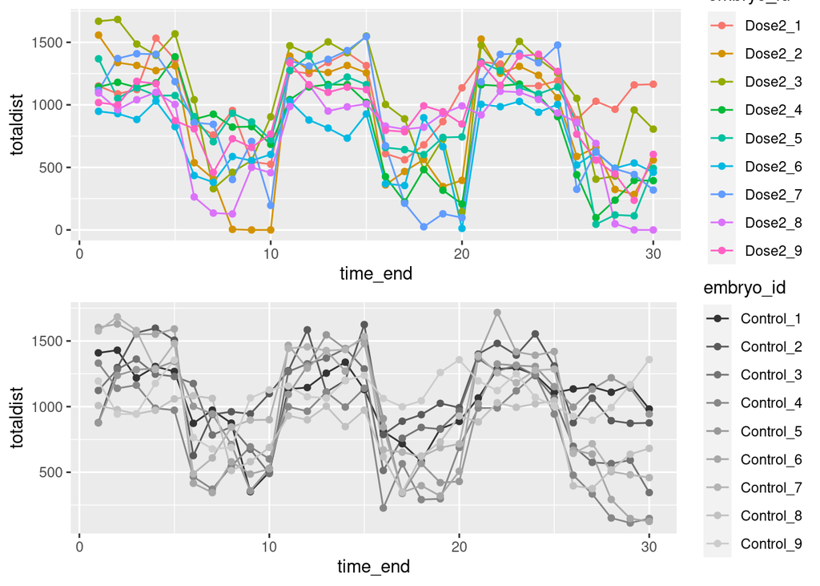

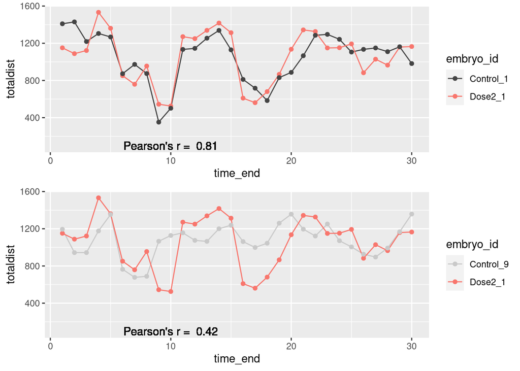

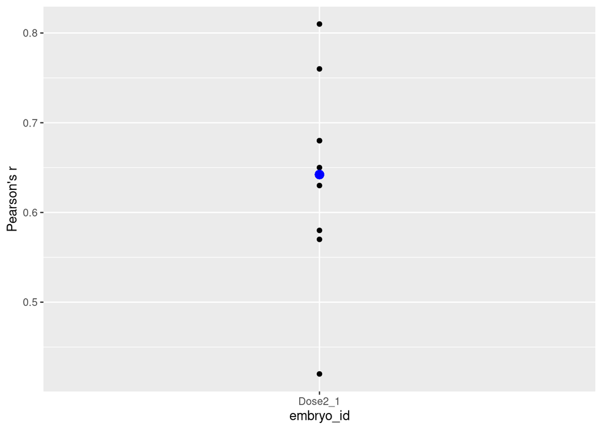

Responses on each plate are normalized using the following equation: `Response = (Vchemical/Vvehicle_control)*100-100`, where Vchemical is the response of the chemical-treated embryo, Vvehicle_control is the median value of the response of the internal plate control embryos. Therefore, response less than 0 from chemical-treated embryos decrease the similarity of their movements when compared to the control embryos. Response greater than 0 increase their similarity to the vehicle control embryos.  
For this reason, it makes the most sense to use a negative direction for the BMD calculation.

#### ANCOVA

[output not shown]

#### Dunnett’s Test

| Chemical | Dose | Difference in similarity score (+/- 100) | P-value | Endpoint |
| --- | --- | --- | --- | --- |
| Fenitrothion | Dose2-C | 34.40088 | 0.0049835 | pearson |
| Fenitrothion | Dose4-C | 34.20513 | 0.0049835 | pearson |
| Fenitrothion | Dose5-C | 32.15402 | 0.0087768 | pearson |
| Malathion | Dose4-C | -25.48622 | 0.0198606 | pearson |

#### Boxplots by endpoint

##### Pearson

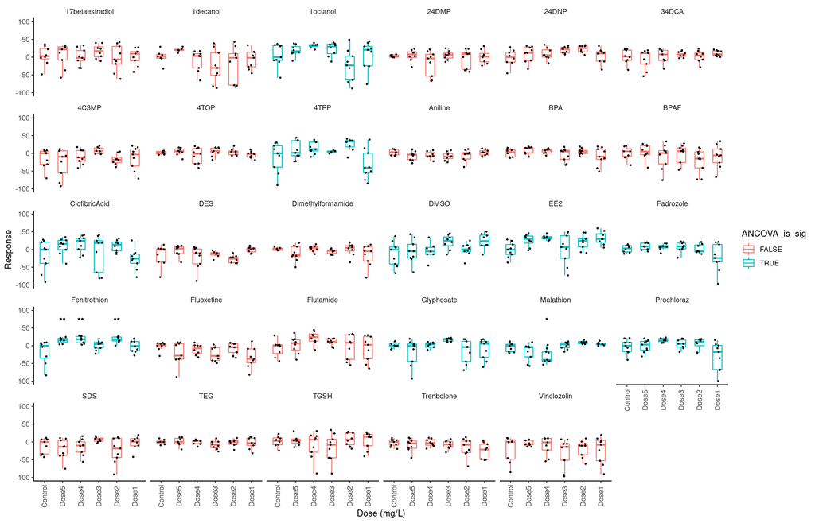

## Similarity Scores/Correlation coefficients

### Benchmark Dose

Since we do not know what the benchmark response is for each one of the chemicals, a method will be used that can estimate a benchmark response (empirically) when given a large enough set of data. The RcurveP package includes an automated process to select an appropriate BMR based off of the data. From Hsieh et al. 2019 manuscript: “The pooled variance of potency of all chemicals per [threshold value (i.e. 5 through 99)] was calculated. The BMR was considered as the [threshold value] at which the potency variance was sufficiently reduced and was the lowest threshold that potency variance was stabilized”. AKA, “the lowest threshold (which gives the highest potency), at which a decrease of variance in potency estimation is stabilized”